# Figure S12: PKA inhibition controls

# Fig S12B

GluA1 S845 phosphorylation relative to total GluA1 with compartment-specific PKA inhibition.

**Source data**  
`Fig S12B.csv`

**Columns**

- `Date` — Experiment date
- `Condition` — Control, Matrix-PKI, or IMS-PKI construct
- `Treatment` — Control or TTX
- `phosphoGluA1_ratio` — GluA1 S845 phosphorylation / total GluA1

## Data

```r
suppressPackageStartupMessages({
  library(readr); library(dplyr); library(ggplot2)
  library(ggbeeswarm); library(ggtext); library(emmeans)
})

condition_order <- c("Control", "Matrix-PKI", "IMS-PKI")
condition_stat_order <- c("Control", "MatrixPKI", "IMSPKI")
treatment_order <- c("Control", "TTX")
group_order <- c("Control Control", "Control TTX", "Matrix-PKI Control",
                 "Matrix-PKI TTX", "IMS-PKI Control", "IMS-PKI TTX")
group_stat_order <- c("Control Control", "Control TTX", "MatrixPKI Control",
                      "MatrixPKI TTX", "IMSPKI Control", "IMSPKI TTX")
spacing_map <- c("Control Control" = 1, "Control TTX" = 2.2,
                 "Matrix-PKI Control" = 4, "Matrix-PKI TTX" = 5.2,
                 "IMS-PKI Control" = 7, "IMS-PKI TTX" = 8.2)
spacing_map_stat <- c("Control Control" = 1, "Control TTX" = 2.2,
                      "MatrixPKI Control" = 4, "MatrixPKI TTX" = 5.2,
                      "IMSPKI Control" = 7, "IMSPKI TTX" = 8.2)

Intensity_df <- read_csv("./Fig S12B.csv", show_col_types = FALSE) %>%
  select(Date, Condition, Treatment, phosphoGluA1_ratio) %>%
  rename(ratio = phosphoGluA1_ratio) %>%
  mutate(Date = as.character(Date),
         Condition = trimws(as.character(Condition)),
         Treatment = trimws(as.character(Treatment)),
         ratio = as.numeric(ratio),
         Condition = case_when(
           Condition == "Control" ~ "Control",
           Condition %in% c("Mt-PKI", "Matrix PKI", "Matrix-PKI") ~ "Matrix-PKI",
           Condition %in% c("IMS-PKI", "IMS PKI") ~ "IMS-PKI",
           TRUE ~ Condition),
         Treatment = case_when(
           Treatment %in% c("Control", "-TTX", "(-TTX)") ~ "Control",
           Treatment %in% c("TTX", "+TTX", "(+TTX)") ~ "TTX",
           TRUE ~ Treatment),
         Condition_stat = case_when(
           Condition == "Control" ~ "Control",
           Condition == "Matrix-PKI" ~ "MatrixPKI",
           Condition == "IMS-PKI" ~ "IMSPKI",
           TRUE ~ Condition),
         Treatment_stat = Treatment,
         Date = factor(Date, levels = sort(unique(Date))),
         Condition = factor(Condition, levels = condition_order),
         Treatment = factor(Treatment, levels = treatment_order),
         Condition_stat = factor(Condition_stat, levels = condition_stat_order),
         Treatment_stat = factor(Treatment_stat, levels = treatment_order),
         Group = factor(paste(Condition, Treatment), levels = group_order),
         Group_stat = factor(paste(Condition_stat, Treatment_stat),
                             levels = group_stat_order),
         x_pos = unname(spacing_map[as.character(Group)])) %>%
  filter(!is.na(Date), !is.na(Condition), !is.na(Treatment),
         !is.na(Group), is.finite(ratio))

design_check <- Intensity_df %>% group_by(Date) %>%
  summarise(n_rows = n(), n_groups = n_distinct(Group), .groups = "drop")

if (any(design_check$n_rows != 6 | design_check$n_groups != 6))
  stop("Each Date must contain exactly one value for all six Condition x Treatment combinations.")

Intensity_df %>%
  transmute(Date, Condition, Treatment,
            phosphoGluA1_ratio = round(ratio, 3))
```

| Date | Condition | Treatment | phosphoGluA1_ratio |
| --- | --- | --- | --- |
| 2026-04-16 | Control | Control | 0.039 |
| 2026-04-16 | Control | TTX | 0.060 |
| 2026-04-16 | Matrix-PKI | Control | 0.036 |
| 2026-04-16 | Matrix-PKI | TTX | 0.064 |
| 2026-04-16 | IMS-PKI | Control | 0.044 |
| 2026-04-16 | IMS-PKI | TTX | 0.068 |
| 2026-05-14 | Control | Control | 0.050 |
| 2026-05-14 | Control | TTX | 0.069 |
| 2026-05-14 | Matrix-PKI | Control | 0.044 |
| 2026-05-14 | Matrix-PKI | TTX | 0.076 |

[output cut: 14 more lines]

## Summary

```r
summary_table <- Intensity_df %>% group_by(Group) %>%
  summarise(mean_ratio = mean(ratio), sd = sd(ratio),
            sem = sd / sqrt(n()), n = n(), .groups = "drop")
summary_table
```

| Group | mean_ratio | sd | sem | n |
| --- | --- | --- | --- | --- |
| Control Control | 0.04282578 | 0.005350520 | 0.002675260 | 4 |
| Control TTX | 0.06883892 | 0.006872922 | 0.003436461 | 4 |
| Matrix-PKI Control | 0.04455393 | 0.008175701 | 0.004087851 | 4 |
| Matrix-PKI TTX | 0.07493455 | 0.015919016 | 0.007959508 | 4 |
| IMS-PKI Control | 0.04549768 | 0.016128371 | 0.008064186 | 4 |
| IMS-PKI TTX | 0.07690545 | 0.018884969 | 0.009442484 | 4 |

## Statistics

Matched two-way ANOVA for construct and treatment, matched by experiment date. Treatment contrasts within construct use Tukey adjustment.

```r
p_stars <- function(p) case_when(
  is.na(p) ~ NA_character_, p < 0.001 ~ "***",
  p < 0.01 ~ "**", p < 0.05 ~ "*", TRUE ~ "ns"
)

options(contrasts = c("contr.sum", "contr.poly"))

fit_aov <- aov(
  ratio ~ Condition_stat * Treatment_stat +
    Error(Date / (Condition_stat * Treatment_stat)),
  data = Intensity_df
)

anova_table <- bind_rows(lapply(summary(fit_aov), function(x)
  tibble::rownames_to_column(as.data.frame(x[[1]]), "Effect"))) %>%
  mutate(Effect = trimws(Effect)) %>%
  filter(Effect %in% c("Condition_stat", "Treatment_stat",
                       "Condition_stat:Treatment_stat")) %>%
  transmute(
    Effect = case_when(
      Effect == "Condition_stat" ~ "Condition",
      Effect == "Treatment_stat" ~ "Treatment",
      Effect == "Condition_stat:Treatment_stat" ~ "Condition x Treatment",
      TRUE ~ Effect
    ),
    df = Df, F = `F value`, p = `Pr(>F)`,
    significance = p_stars(p)
  )

anova_table
```

| Effect | df | F | p | significance |
| --- | --- | --- | --- | --- |
| Condition | 2 | 0.2976860 | 0.752897521 | ns |
| Treatment | 1 | 97.0933537 | 0.002222357 | ** |
| Condition x Treatment | 2 | 0.2760798 | 0.767892373 | ns |

```r
emm_treatment <- emmeans(fit_aov, ~ Treatment_stat | Condition_stat) %>%
  contrast(method = "pairwise", adjust = "tukey") %>%
  as.data.frame() %>%
  mutate(
    contrast = as.character(contrast),
    comparison_type = "Treatment within Condition",
    level1 = sapply(strsplit(contrast, " - ", fixed = TRUE), `[`, 1),
    level2 = sapply(strsplit(contrast, " - ", fixed = TRUE), `[`, 2),
    group1 = paste(Condition_stat, level1),
    group2 = paste(Condition_stat, level2)
  )

emm_condition <- emmeans(fit_aov, ~ Condition_stat | Treatment_stat) %>%
  contrast(method = "pairwise", adjust = "tukey") %>%
  as.data.frame() %>%
  mutate(
    contrast = as.character(contrast),
    comparison_type = "Condition within Treatment",
    level1 = sapply(strsplit(contrast, " - ", fixed = TRUE), `[`, 1),
    level2 = sapply(strsplit(contrast, " - ", fixed = TRUE), `[`, 2),
    group1 = paste(level1, Treatment_stat),
    group2 = paste(level2, Treatment_stat)
  )

posthoc_table <- bind_rows(
  emm_treatment %>%
    select(comparison_type, group1, group2, estimate, SE, df, t.ratio, p.value),
  emm_condition %>%
    select(comparison_type, group1, group2, estimate, SE, df, t.ratio, p.value)
) %>%
  rename(p.adj = p.value) %>%
  mutate(p.signif = p_stars(p.adj))

posthoc_table
```

| comparison_type | group1 | group2 | estimate | SE | df | t.ratio | p.adj | p.signif |
| --- | --- | --- | --- | --- | --- | --- | --- | --- |
| Treatment within Condition | Control Control | Control TTX | -0.026013150 | 0.005351258 | 8.974241 | -4.8611276 | 0.0009018407 | *** |
| Treatment within Condition | MatrixPKI Control | MatrixPKI TTX | -0.030380625 | 0.005351258 | 8.974241 | -5.6772861 | 0.0003061355 | *** |
| Treatment within Condition | IMSPKI Control | IMSPKI TTX | -0.031407775 | 0.005351258 | 8.974241 | -5.8692316 | 0.0002406591 | *** |
| Condition within Treatment | Control Control | MatrixPKI Control | -0.001728150 | 0.008164218 | 9.181092 | -0.2116737 | 0.9756672768 | ns |
| Condition within Treatment | Control Control | IMSPKI Control | -0.002671900 | 0.008164218 | 9.181092 | -0.3272695 | 0.9430293519 | ns |
| Condition within Treatment | MatrixPKI Control | IMSPKI Control | -0.000943750 | 0.008164218 | 9.181092 | -0.1155959 | 0.9926661015 | ns |
| Condition within Treatment | Control TTX | MatrixPKI TTX | -0.006095625 | 0.008164218 | 9.181092 | -0.7466269 | 0.7429663558 | ns |
| Condition within Treatment | Control TTX | IMSPKI TTX | -0.008066525 | 0.008164218 | 9.181092 | -0.9880340 | 0.6017800628 | ns |
| Condition within Treatment | MatrixPKI TTX | IMSPKI TTX | -0.001970900 | 0.008164218 | 9.181092 | -0.2414071 | 0.9684936696 | ns |

## Plot

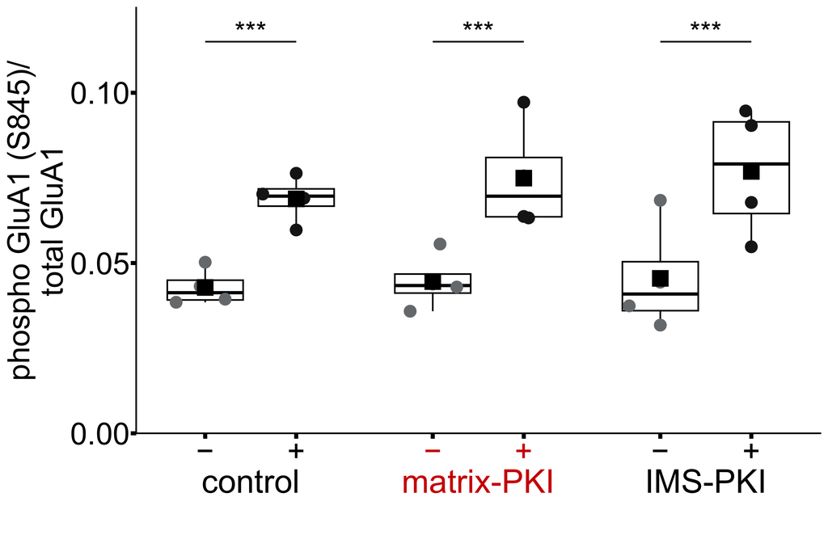

```r
set.seed(20261109)
label_red <- "#D00000"
group_colors <- c("Control Control" = "#777B7E", "Control TTX" = "#1A1A1A",
                  "Matrix-PKI Control" = "#777B7E", "Matrix-PKI TTX" = "#1A1A1A",
                  "IMS-PKI Control" = "#777B7E", "IMS-PKI TTX" = "#1A1A1A")

get_posthoc <- function(g1, g2) {
  out <- posthoc_table %>%
    filter((group1 == g1 & group2 == g2) | (group1 == g2 & group2 == g1))
  if (!nrow(out))
    return(tibble(group1 = g1, group2 = g2, p.adj = NA_real_,
                  p.signif = NA_character_))
  out %>% slice(1) %>% mutate(group1 = g1, group2 = g2)
}

stats_plot <- bind_rows(
  get_posthoc("Control Control", "Control TTX"),
  get_posthoc("MatrixPKI Control", "MatrixPKI TTX"),
  get_posthoc("IMSPKI Control", "IMSPKI TTX")
) %>%
  filter(!is.na(p.adj), p.adj < 0.05) %>%
  mutate(x1 = unname(spacing_map_stat[group1]),
         x2 = unname(spacing_map_stat[group2]),
         y_position = 0.115, x_mid = (x1 + x2) / 2)

group_labels <- tibble(x = c(1.6, 4.6, 7.6), y = -0.014,
                       label = c("control", "matrix-PKI", "IMS-PKI"))

tick_labels <- c(
  "<span>−</span>", "<span>+</span>",
  paste0("<span style='color:", label_red, "'>−</span>"),
  paste0("<span style='color:", label_red, "'>+</span>"),
  "<span>−</span>", "<span>+</span>"
)

figs12b_plot <- ggplot(Intensity_df, aes(x_pos, ratio, color = Group)) +
  geom_boxplot(aes(group = x_pos), fill = NA, width = 1,
               outlier.shape = NA, linewidth = 2, color = "black") +
  ggbeeswarm::geom_beeswarm(cex = 9, priority = "random", size = 15,
                            alpha = 1, corral = "random") +
  stat_summary(aes(group = x_pos), fun = mean, geom = "point",
               shape = 15, size = 20, color = "black") +
  geom_segment(data = stats_plot,
               aes(x = x1, xend = x2, y = y_position, yend = y_position),
               inherit.aes = FALSE, linewidth = 2, color = "black") +
  geom_text(data = stats_plot,
            aes(x = x_mid, y = y_position + 0.003, label = p.signif),
            inherit.aes = FALSE, size = 25, color = "black") +
  geom_text(data = filter(group_labels, label != "matrix-PKI"),
            aes(x, y, label = label), inherit.aes = FALSE,
            size = 30, color = "black") +
  geom_text(data = filter(group_labels, label == "matrix-PKI"),
            aes(x, y, label = label), inherit.aes = FALSE,
            size = 30, color = label_red) +
  scale_x_continuous(breaks = unname(spacing_map), labels = tick_labels) +
  scale_color_manual(values = group_colors, breaks = group_order) +
  scale_y_continuous(breaks = c(0, 0.05, 0.1), expand = c(0, 0)) +
  coord_cartesian(ylim = c(0, 0.125), clip = "off") +
  labs(x = NULL, y = "phospho GluA1 (S845)/\ntotal GluA1") +
  theme_classic() +
  theme(axis.title = element_text(size = 80, color = "black"),
        axis.text = element_text(size = 80, color = "black"),
        axis.text.x = ggtext::element_markdown(size = 80, color = "black"),
        axis.ticks = element_line(linewidth = 5, color = "black"),
        axis.ticks.length = grid::unit(0.5, "cm"),
        axis.line = element_line(linewidth = 2, color = "black"),
        plot.margin = margin(20, 20, 220, 20),
        legend.position = "none")

figs12b_plot
```

# Fig S12D

GluN1 S897 phosphorylation relative to total GluN1 with compartment-specific PKA inhibition.

**Source data**  
`Fig S12D.csv`

**Columns**

- `Date` — Experiment date
- `Condition` — Control, Matrix-PKI, or IMS-PKI construct
- `Treatment` — Control or TTX
- `phosphoGluN1_ratio` — GluN1 S897 phosphorylation / total GluN1

## Data

```r
suppressPackageStartupMessages({
  library(readr); library(dplyr); library(ggplot2)
  library(ggbeeswarm); library(ggtext); library(emmeans)
})

condition_order <- c("Control", "Matrix-PKI", "IMS-PKI")
condition_stat_order <- c("Control", "MatrixPKI", "IMSPKI")
treatment_order <- c("Control", "TTX")
group_order <- c("Control Control", "Control TTX", "Matrix-PKI Control",
                 "Matrix-PKI TTX", "IMS-PKI Control", "IMS-PKI TTX")
group_stat_order <- c("Control Control", "Control TTX", "MatrixPKI Control",
                      "MatrixPKI TTX", "IMSPKI Control", "IMSPKI TTX")
spacing_map <- c("Control Control" = 1, "Control TTX" = 2.2,
                 "Matrix-PKI Control" = 4, "Matrix-PKI TTX" = 5.2,
                 "IMS-PKI Control" = 7, "IMS-PKI TTX" = 8.2)
spacing_map_stat <- c("Control Control" = 1, "Control TTX" = 2.2,
                      "MatrixPKI Control" = 4, "MatrixPKI TTX" = 5.2,
                      "IMSPKI Control" = 7, "IMSPKI TTX" = 8.2)

Intensity_df <- read_csv("./Fig S12D.csv", show_col_types = FALSE) %>%
  select(Date, Condition, Treatment, phosphoGluN1_ratio) %>%
  rename(ratio = phosphoGluN1_ratio) %>%
  mutate(Date = as.character(Date),
         Condition = trimws(as.character(Condition)),
         Treatment = trimws(as.character(Treatment)),
         ratio = as.numeric(ratio),
         Condition = case_when(
           Condition == "Control" ~ "Control",
           Condition %in% c("Mt-PKI", "Matrix PKI", "Matrix-PKI") ~ "Matrix-PKI",
           Condition %in% c("IMS-PKI", "IMS PKI") ~ "IMS-PKI",
           TRUE ~ Condition),
         Treatment = case_when(
           Treatment %in% c("Control", "-TTX", "(-TTX)") ~ "Control",
           Treatment %in% c("TTX", "+TTX", "(+TTX)") ~ "TTX",
           TRUE ~ Treatment),
         Condition_stat = case_when(
           Condition == "Control" ~ "Control",
           Condition == "Matrix-PKI" ~ "MatrixPKI",
           Condition == "IMS-PKI" ~ "IMSPKI",
           TRUE ~ Condition),
         Treatment_stat = Treatment,
         Date = factor(Date, levels = sort(unique(Date))),
         Condition = factor(Condition, levels = condition_order),
         Treatment = factor(Treatment, levels = treatment_order),
         Condition_stat = factor(Condition_stat, levels = condition_stat_order),
         Treatment_stat = factor(Treatment_stat, levels = treatment_order),
         Group = factor(paste(Condition, Treatment), levels = group_order),
         Group_stat = factor(paste(Condition_stat, Treatment_stat),
                             levels = group_stat_order),
         x_pos = unname(spacing_map[as.character(Group)])) %>%
  filter(!is.na(Date), !is.na(Condition), !is.na(Treatment),
         !is.na(Group), is.finite(ratio))

design_check <- Intensity_df %>% group_by(Date) %>%
  summarise(n_rows = n(), n_groups = n_distinct(Group), .groups = "drop")

if (any(design_check$n_rows != 6 | design_check$n_groups != 6))
  stop("Each Date must contain exactly one value for all six Condition x Treatment combinations.")

Intensity_df %>%
  transmute(Date, Condition, Treatment, phosphoGluN1_ratio = round(ratio, 3))
```

| Date | Condition | Treatment | phosphoGluN1_ratio |
| --- | --- | --- | --- |
| 2026-04-16 | Control | Control | 0.029 |
| 2026-04-16 | Control | TTX | 0.043 |
| 2026-04-16 | Matrix-PKI | Control | 0.048 |
| 2026-04-16 | Matrix-PKI | TTX | 0.073 |
| 2026-04-16 | IMS-PKI | Control | 0.060 |
| 2026-04-16 | IMS-PKI | TTX | 0.063 |
| 2026-05-14 | Control | Control | 0.047 |
| 2026-05-14 | Control | TTX | 0.064 |
| 2026-05-14 | Matrix-PKI | Control | 0.061 |
| 2026-05-14 | Matrix-PKI | TTX | 0.088 |

[output cut: 14 more lines]

## Summary

```r
summary_table <- Intensity_df %>% group_by(Group) %>%
  summarise(mean_ratio = mean(ratio), sd = sd(ratio),
            sem = sd / sqrt(n()), n = n(), .groups = "drop")
summary_table
```

| Group | mean_ratio | sd | sem | n |
| --- | --- | --- | --- | --- |
| Control Control | 0.03940213 | 0.01182867 | 0.005914335 | 4 |
| Control TTX | 0.05143595 | 0.01290712 | 0.006453561 | 4 |
| Matrix-PKI Control | 0.03856052 | 0.02125415 | 0.010627075 | 4 |
| Matrix-PKI TTX | 0.06127265 | 0.02488300 | 0.012441501 | 4 |
| IMS-PKI Control | 0.04542327 | 0.01741602 | 0.008708008 | 4 |
| IMS-PKI TTX | 0.05825993 | 0.00679437 | 0.003397185 | 4 |

## Statistics

Matched two-way ANOVA for construct and treatment, matched by experiment date. Treatment contrasts within construct use Tukey adjustment.

```r
p_stars <- function(p) case_when(
  is.na(p) ~ NA_character_, p < 0.001 ~ "***",
  p < 0.01 ~ "**", p < 0.05 ~ "*", TRUE ~ "ns"
)

options(contrasts = c("contr.sum", "contr.poly"))

fit_aov <- aov(
  ratio ~ Condition_stat * Treatment_stat +
    Error(Date / (Condition_stat * Treatment_stat)),
  data = Intensity_df
)

anova_table <- bind_rows(lapply(summary(fit_aov), function(x)
  tibble::rownames_to_column(as.data.frame(x[[1]]), "Effect"))) %>%
  mutate(Effect = trimws(Effect)) %>%
  filter(Effect %in% c("Condition_stat", "Treatment_stat",
                       "Condition_stat:Treatment_stat")) %>%
  transmute(
    Effect = case_when(
      Effect == "Condition_stat" ~ "Condition",
      Effect == "Treatment_stat" ~ "Treatment",
      Effect == "Condition_stat:Treatment_stat" ~ "Condition x Treatment",
      TRUE ~ Effect
    ),
    df = Df, F = `F value`, p = `Pr(>F)`,
    significance = p_stars(p)
  )

anova_table
```

| Effect | df | F | p | significance |
| --- | --- | --- | --- | --- |
| Condition | 2 | 0.2058009 | 0.8195097162 | ns |
| Treatment | 1 | 519.8091387 | 0.0001848014 | *** |
| Condition x Treatment | 2 | 1.9294823 | 0.2254030701 | ns |

```r
emm_treatment <- emmeans(fit_aov, ~ Treatment_stat | Condition_stat) %>%
  contrast(method = "pairwise", adjust = "tukey") %>%
  as.data.frame() %>%
  mutate(
    contrast = as.character(contrast),
    comparison_type = "Treatment within Condition",
    level1 = sapply(strsplit(contrast, " - ", fixed = TRUE), `[`, 1),
    level2 = sapply(strsplit(contrast, " - ", fixed = TRUE), `[`, 2),
    group1 = paste(Condition_stat, level1),
    group2 = paste(Condition_stat, level2)
  )

emm_condition <- emmeans(fit_aov, ~ Condition_stat | Treatment_stat) %>%
  contrast(method = "pairwise", adjust = "tukey") %>%
  as.data.frame() %>%
  mutate(
    contrast = as.character(contrast),
    comparison_type = "Condition within Treatment",
    level1 = sapply(strsplit(contrast, " - ", fixed = TRUE), `[`, 1),
    level2 = sapply(strsplit(contrast, " - ", fixed = TRUE), `[`, 2),
    group1 = paste(level1, Treatment_stat),
    group2 = paste(level2, Treatment_stat)
  )

posthoc_table <- bind_rows(
  emm_treatment %>%
    select(comparison_type, group1, group2, estimate, SE, df, t.ratio, p.value),
  emm_condition %>%
    select(comparison_type, group1, group2, estimate, SE, df, t.ratio, p.value)
) %>%
  rename(p.adj = p.value) %>%
  mutate(p.signif = p_stars(p.adj))

posthoc_table
```

| comparison_type | group1 | group2 | estimate | SE | df | t.ratio | p.adj | p.signif |
| --- | --- | --- | --- | --- | --- | --- | --- | --- |
| Treatment within Condition | Control Control | Control TTX | -0.012033825 | 0.00356419 | 6.464399 | -3.37631396 | 0.013324966 | * |
| Treatment within Condition | MatrixPKI Control | MatrixPKI TTX | -0.022712125 | 0.00356419 | 6.464399 | -6.37231011 | 0.000521506 | *** |
| Treatment within Condition | IMSPKI Control | IMSPKI TTX | -0.012836650 | 0.00356419 | 6.464399 | -3.60156148 | 0.009986690 | ** |
| Condition within Treatment | Control Control | MatrixPKI Control | 0.000841600 | 0.01071171 | 7.033880 | 0.07856825 | 0.996604145 | ns |
| Condition within Treatment | Control Control | IMSPKI Control | -0.006021150 | 0.01071171 | 7.033880 | -0.56210934 | 0.843757690 | ns |
| Condition within Treatment | MatrixPKI Control | IMSPKI Control | -0.006862750 | 0.01071171 | 7.033880 | -0.64067759 | 0.803242248 | ns |
| Condition within Treatment | Control TTX | MatrixPKI TTX | -0.009836700 | 0.01071171 | 7.033880 | -0.91831310 | 0.646714579 | ns |
| Condition within Treatment | Control TTX | IMSPKI TTX | -0.006823975 | 0.01071171 | 7.033880 | -0.63705772 | 0.805165935 | ns |
| Condition within Treatment | MatrixPKI TTX | IMSPKI TTX | 0.003012725 | 0.01071171 | 7.033880 | 0.28125539 | 0.957590232 | ns |

## Plot

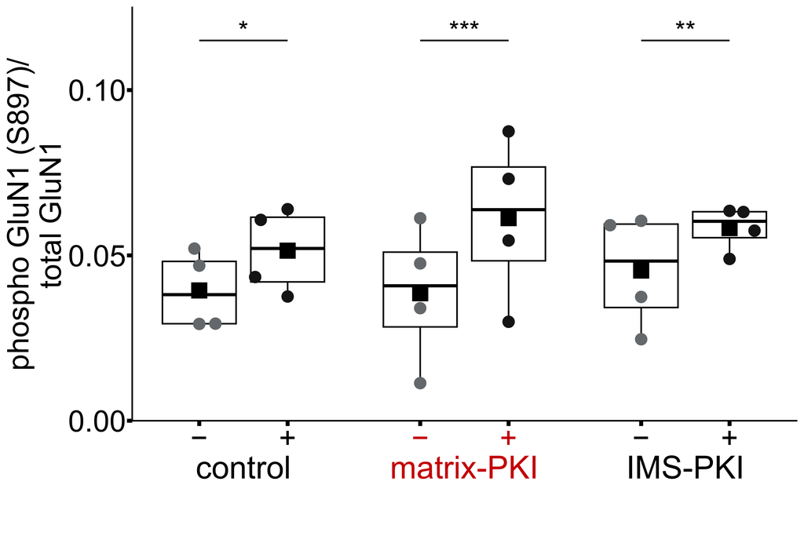

```r
set.seed(20261109)
label_red <- "#D00000"
group_colors <- c("Control Control" = "#777B7E", "Control TTX" = "#1A1A1A",
                  "Matrix-PKI Control" = "#777B7E", "Matrix-PKI TTX" = "#1A1A1A",
                  "IMS-PKI Control" = "#777B7E", "IMS-PKI TTX" = "#1A1A1A")

get_posthoc <- function(g1, g2) {
  out <- posthoc_table %>%
    filter((group1 == g1 & group2 == g2) | (group1 == g2 & group2 == g1))
  if (!nrow(out))
    return(tibble(group1 = g1, group2 = g2, p.adj = NA_real_,
                  p.signif = NA_character_))
  out %>% slice(1) %>% mutate(group1 = g1, group2 = g2)
}

stats_plot <- bind_rows(
  get_posthoc("Control Control", "Control TTX"),
  get_posthoc("MatrixPKI Control", "MatrixPKI TTX"),
  get_posthoc("IMSPKI Control", "IMSPKI TTX")
) %>%
  filter(!is.na(p.adj), p.adj < 0.05) %>%
  mutate(x1 = unname(spacing_map_stat[group1]),
         x2 = unname(spacing_map_stat[group2]),
         y_position = 0.115, x_mid = (x1 + x2) / 2)

group_labels <- tibble(x = c(1.6, 4.6, 7.6), y = -0.014,
                       label = c("control", "matrix-PKI", "IMS-PKI"))

tick_labels <- c(
  "<span>−</span>", "<span>+</span>",
  paste0("<span style='color:", label_red, "'>−</span>"),
  paste0("<span style='color:", label_red, "'>+</span>"),
  "<span>−</span>", "<span>+</span>"
)

figs12d_plot <- ggplot(Intensity_df, aes(x_pos, ratio, color = Group)) +
  geom_boxplot(aes(group = x_pos), fill = NA, width = 1,
               outlier.shape = NA, linewidth = 2, color = "black") +
  ggbeeswarm::geom_beeswarm(cex = 9, priority = "random", size = 15, corral = "random") +
  stat_summary(aes(group = x_pos), fun = mean, geom = "point",
               shape = 15, size = 20, color = "black") +
  geom_segment(data = stats_plot,
               aes(x = x1, xend = x2, y = y_position, yend = y_position),
               inherit.aes = FALSE, linewidth = 2, color = "black") +
  geom_text(data = stats_plot,
            aes(x = x_mid, y = y_position + 0.003, label = p.signif),
            inherit.aes = FALSE, size = 25, color = "black") +
  geom_text(data = filter(group_labels, label != "matrix-PKI"),
            aes(x, y, label = label), inherit.aes = FALSE,
            size = 30, color = "black") +
  geom_text(data = filter(group_labels, label == "matrix-PKI"),
            aes(x, y, label = label), inherit.aes = FALSE,
            size = 30, color = label_red) +
  scale_x_continuous(breaks = unname(spacing_map), labels = tick_labels) +
  scale_color_manual(values = group_colors, breaks = group_order) +
  scale_y_continuous(breaks = c(0, 0.05, 0.1), expand = c(0, 0)) +
  coord_cartesian(ylim = c(0, 0.125), clip = "off") +
  labs(x = NULL, y = "phospho GluN1 (S897)/\ntotal GluN1") +
  theme_classic() +
  theme(axis.title = element_text(size = 80, color = "black"),
        axis.text = element_text(size = 80, color = "black"),
        axis.text.x = ggtext::element_markdown(size = 80, color = "black"),
        axis.ticks = element_line(linewidth = 5, color = "black"),
        axis.ticks.length = grid::unit(0.5, "cm"),
        axis.line = element_line(linewidth = 2, color = "black"),
        plot.margin = margin(20, 20, 220, 20),
        legend.position = "none")

figs12d_plot
```

# Fig S12E

Mitochondrial pH after homeostatic plasticity in Matrix-PKI-expressing neurons.

**Source data**  
`Fig S12E.csv`

**Columns**

- `Date` — Experiment date
- `Condition` — Control or TTX
- `Dish` — Culture dish ID
- `Cell` — Cell ID
- `Mito_ID` — Mitochondrial trace ID
- `Frame` — Imaging frame
- `Intensity` — pH sensor fluorescence

## Data

pH is estimated per trace using mean fluorescence over the first ten frames, peak fluorescence, pKa 7.1, and a reference pH of 7.4.

```r
suppressPackageStartupMessages({
  library(dplyr); library(readr); library(ggplot2); library(ggbeeswarm); library(ggtext)
})

pKa <- 7.1
spacing_map <- c("Control MitoPKI" = 1, "TTX MitoPKI" = 2.2)
condition_labels <- c("Control MitoPKI" = "Control", "TTX MitoPKI" = "TTX")

Mito_pH_df <- read_csv("./Fig S12E.csv", show_col_types = FALSE) %>%
  transmute(Date = trimws(as.character(Date)), Condition = trimws(as.character(Condition)),
            Dish = as.numeric(Dish), Cell = as.numeric(Cell), Mito_ID = as.character(Mito_ID),
            Frame = as.numeric(Frame), Intensity = as.numeric(Intensity)) %>%
  filter(Condition %in% names(spacing_map), Date != "", is.finite(Frame), is.finite(Intensity)) %>%
  group_by(Date, Condition, Dish, Cell, Mito_ID, Frame) %>%
  summarise(Intensity = mean(Intensity, na.rm = TRUE), .groups = "drop") %>%
  arrange(Date, Condition, Dish, Cell, Mito_ID, Frame) %>%
  group_by(Date, Condition, Dish, Cell, Mito_ID) %>%
  summarise(F0 = mean(head(Intensity, 10)), Fmax = max(Intensity),
            n_Frames = n_distinct(Frame), .groups = "drop") %>%
  filter(n_Frames >= 10, is.finite(F0), is.finite(Fmax), F0 > 0, Fmax > 0) %>%
  mutate(Mito_pH = pKa - log10(((1 + 10^(pKa - 7.4)) / (F0 / Fmax)) - 1)) %>%
  filter(is.finite(Mito_pH)) %>%
  mutate(Condition = factor(Condition, levels = names(spacing_map)),
         Date = factor(Date), x_pos = unname(spacing_map[as.character(Condition)]),
         Date_Condition = paste(Condition, Date, sep = "_"))

if (!nrow(Mito_pH_df)) stop("No valid mitochondrial pH measurements remain.")

Mito_pH_df %>%
  transmute(Date, Condition = unname(condition_labels[as.character(Condition)]),
            Dish, Cell, Mito_ID, Mito_pH = round(Mito_pH, 3))
```

| Date | Condition | Dish | Cell | Mito_ID | Mito_pH |
| --- | --- | --- | --- | --- | --- |
| 2026-06-25 | Control | 1 | 1 | 1 | 7.099 |
| 2026-06-25 | Control | 1 | 1 | 10 | 7.206 |
| 2026-06-25 | Control | 1 | 1 | 11 | 7.001 |
| 2026-06-25 | Control | 1 | 1 | 12 | 7.187 |
| 2026-06-25 | Control | 1 | 1 | 13 | 7.256 |
| 2026-06-25 | Control | 1 | 1 | 14 | 7.131 |
| 2026-06-25 | Control | 1 | 1 | 15 | 7.222 |
| 2026-06-25 | Control | 1 | 1 | 2 | 7.237 |
| 2026-06-25 | Control | 1 | 1 | 3 | 7.175 |
| 2026-06-25 | Control | 1 | 1 | 4 | 7.167 |

[output cut: 149 more lines]

## Summary

```r
summary_table <- Mito_pH_df %>%
  group_by(Condition) %>%
  summarise(n_Mitochondria = n(), n_Cells = n_distinct(Date, Dish, Cell),
            n_Experiment_Dates = n_distinct(Date), Mean = mean(Mito_pH),
            SE = sd(Mito_pH) / sqrt(n()), .groups = "drop") %>%
  mutate(Condition = unname(condition_labels[as.character(Condition)]),
         across(c(Mean, SE), \(x) round(x, 3)))

summary_table
```

| Condition | n_Mitochondria | n_Cells | n_Experiment_Dates | Mean | SE |
| --- | --- | --- | --- | --- | --- |
| Control | 74 | 6 | 3 | 7.048 | 0.022 |
| TTX | 85 | 6 | 3 | 6.981 | 0.025 |

## Statistics

Two-way ANOVA with condition, experiment date, and their interaction (Type I sums of squares).

```r
format_p <- function(p) ifelse(p < 0.0001, "<0.0001", sprintf("%.4f", p))
p_to_stars <- function(p) case_when(
  p < 0.001 ~ "***", p < 0.01 ~ "**", p < 0.05 ~ "*", TRUE ~ "ns"
)

fit_aov <- aov(Mito_pH ~ Condition * Date, data = Mito_pH_df)
anova_results <- anova(fit_aov)
condition_p <- as.numeric(anova_results["Condition", "Pr(>F)"])

anova_table <- as.data.frame(anova_results) %>%
  tibble::rownames_to_column("Effect") %>%
  filter(trimws(Effect) != "Residuals") %>%
  transmute(Test = "Two-way ANOVA", Effect = gsub(":", " x ", trimws(Effect)),
            df = Df, F = round(`F value`, 3), `p value` = format_p(`Pr(>F)`))

group_means <- Mito_pH_df %>%
  group_by(Condition) %>%
  summarise(Mean = mean(Mito_pH), SE = sd(Mito_pH) / sqrt(n()), .groups = "drop")

stats_table <- tibble(
  Test = "Two-way ANOVA", Comparison = "Control vs TTX",
  `Control mean (SE)` = sprintf("%.3f (%.3f)", group_means$Mean[1], group_means$SE[1]),
  `TTX mean (SE)` = sprintf("%.3f (%.3f)", group_means$Mean[2], group_means$SE[2]),
  `Condition p` = format_p(condition_p)
)

anova_table
```

| Test | Effect | df | F | p value |
| --- | --- | --- | --- | --- |
| Two-way ANOVA | Condition | 1 | 3.979 | 0.0479 |
| Two-way ANOVA | Date | 2 | 0.190 | 0.8276 |
| Two-way ANOVA | Condition x Date | 2 | 4.318 | 0.0150 |

```r
stats_table
```

| Test | Comparison | Control mean (SE) | TTX mean (SE) | Condition p |
| --- | --- | --- | --- | --- |
| Two-way ANOVA | Control vs TTX | 7.048 (0.022) | 6.981 (0.025) | 0.0479 |

## Plot

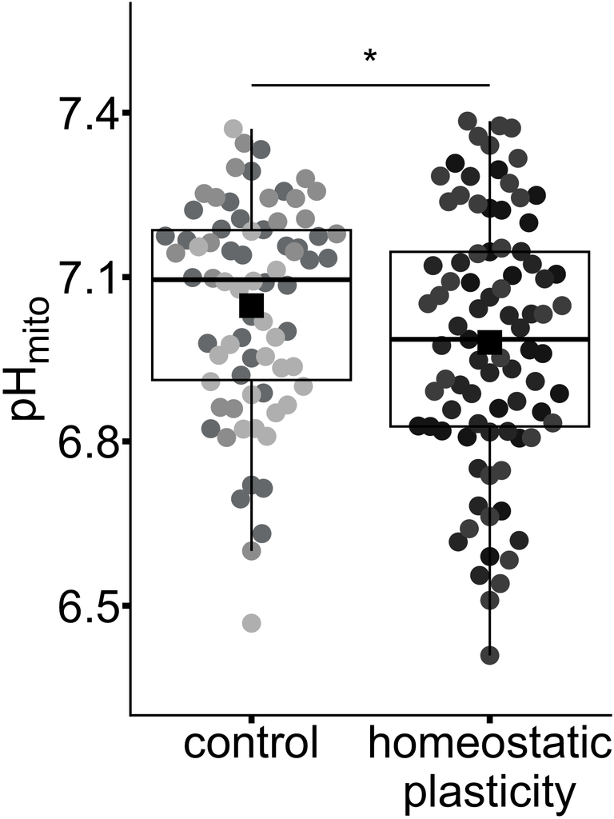

```r
set.seed(20261109)
date_levels <- levels(Mito_pH_df$Date)
date_colors <- c(
  setNames(rep(c("#777B7E", "#9E9E9E", "#BDBDBD"), length.out = length(date_levels)),
           paste("Control MitoPKI", date_levels, sep = "_")),
  setNames(rep(c("#1A1A1A", "#303030", "#4D4D4D"), length.out = length(date_levels)),
           paste("TTX MitoPKI", date_levels, sep = "_"))
)

plot_stats <- tibble(x1 = 1, x2 = 2.2, y = 7.45,
                     stars = p_to_stars(condition_p)) %>%
  filter(stars != "ns")

figs12e_plot <- ggplot(Mito_pH_df, aes(x_pos, Mito_pH, color = Date_Condition)) +
  ggbeeswarm::geom_beeswarm(cex = 5, priority = "random", size = 15, corral = "random") +
  geom_boxplot(aes(group = x_pos), fill = NA, width = 1, outlier.shape = NA,
               linewidth = 2, color = "black") +
  stat_summary(aes(group = x_pos), fun = mean, geom = "point",
               shape = 15, size = 20, color = "black") +
  geom_segment(data = plot_stats, aes(x = x1, xend = x2, y = y, yend = y),
               inherit.aes = FALSE, linewidth = 2, color = "black") +
  geom_text(data = plot_stats, aes(x = (x1 + x2) / 2, y = y + 0.04, label = stars),
            inherit.aes = FALSE, size = 25, color = "black") +
  scale_x_continuous(breaks = unname(spacing_map),
                     labels = c("control", "homeostatic\nplasticity")) +
  scale_color_manual(values = date_colors) +
  scale_y_continuous(oob = scales::oob_keep, breaks = c(6.5, 6.8, 7.1, 7.4),
                     limits = c(6.3, 7.6), expand = c(0, 0)) +
  labs(x = NULL, y = "pH<sub>mito</sub>") +
  theme_classic() +
  theme(axis.title.y = ggtext::element_markdown(size = 80, color = "black"),
        axis.text = element_text(size = 80, color = "black"),
        axis.ticks = element_line(linewidth = 5, color = "black"),
        axis.ticks.length = grid::unit(0.5, "cm"),
        axis.line = element_line(linewidth = 2, color = "black"),
        legend.position = "none")

figs12e_plot
```

# Fig S12F

mEPSC peak-amplitude distribution following homeostatic plasticity in Matrix-PKI-expressing neurons.

**Source data**  
`Fig S12F.csv`

**Columns**

- `Date` — Experiment date
- `Condition` — Control or TTX
- `Cell` — Cell ID
- `Peak_Amp` — Signed mEPSC peak amplitude (pA)

## Data

```r
suppressPackageStartupMessages({
  library(dplyr); library(readr); library(ggplot2)
})

REMOVE_CONTROL <- TRUE
condition_order <- c("Control", "Control MitoPKI", "TTX MitoPKI")
condition_colors <- c("Control" = "#BDBDBD", "Control MitoPKI" = "#9E9E9E", "TTX MitoPKI" = "#1A1A1A")

Events <- read_csv("./Fig S12F.csv", show_col_types = FALSE) %>%
  transmute(Date = trimws(as.character(Date)), Condition = trimws(as.character(Condition)),
            Cell = as.character(Cell), Peak_Amp = as.numeric(Peak_Amp)) %>%
  filter(Condition %in% condition_order, Date != "", is.finite(Peak_Amp)) %>%
  mutate(Condition = factor(Condition, levels = condition_order))

if (REMOVE_CONTROL) Events <- Events %>% filter(Condition != "Control") %>% droplevels()
if (n_distinct(Events$Condition) < 2) stop("At least two conditions are required.")

Events %>% mutate(Peak_Amp = round(Peak_Amp, 3))
```

| Date | Condition | Cell | Peak_Amp |
| --- | --- | --- | --- |
| 2026-07-23 | Control MitoPKI | 1 | -6.812 |
| 2026-07-23 | Control MitoPKI | 1 | -5.958 |
| 2026-07-23 | Control MitoPKI | 1 | -8.971 |
| 2026-07-23 | Control MitoPKI | 1 | -6.633 |
| 2026-07-23 | Control MitoPKI | 1 | -5.704 |
| 2026-07-23 | Control MitoPKI | 1 | -7.104 |
| 2026-07-23 | Control MitoPKI | 1 | -7.316 |
| 2026-07-23 | Control MitoPKI | 2 | -5.563 |
| 2026-07-23 | Control MitoPKI | 2 | -6.636 |
| 2026-07-23 | Control MitoPKI | 2 | -5.719 |

[output cut: 207 more lines]

## Summary

```r
summary_table <- Events %>%
  group_by(Condition) %>%
  summarise(n_Events = n(), n_Cells = n_distinct(Date, Cell),
            n_Experiment_Dates = n_distinct(Date), .groups = "drop")

summary_table
```

| Condition | n_Events | n_Cells | n_Experiment_Dates |
| --- | --- | --- | --- |
| Control MitoPKI | 100 | 9 | 3 |
| TTX MitoPKI | 117 | 11 | 3 |

## Statistics

Two-sided Kolmogorov–Smirnov test on signed event amplitudes.

```r
format_p <- function(p) ifelse(p < 0.0001, "<0.0001", sprintf("%.4f", p))
condition_pairs <- combn(levels(Events$Condition), 2, simplify = FALSE)

stats_table <- bind_rows(lapply(condition_pairs, function(pair) {
  test <- suppressWarnings(ks.test(
    Events %>% filter(Condition == pair[1]) %>% pull(Peak_Amp),
    Events %>% filter(Condition == pair[2]) %>% pull(Peak_Amp)
  ))
  tibble(Test = "Kolmogorov-Smirnov test",
         Comparison = paste(pair, collapse = " vs "),
         D = round(unname(test$statistic), 3),
         `p value` = format_p(test$p.value))
}))

stats_table
```

| Test | Comparison | D | p value |
| --- | --- | --- | --- |
| Kolmogorov-Smirnov test | Control MitoPKI vs TTX MitoPKI | 0.302 | 0.0001 |

## Plot

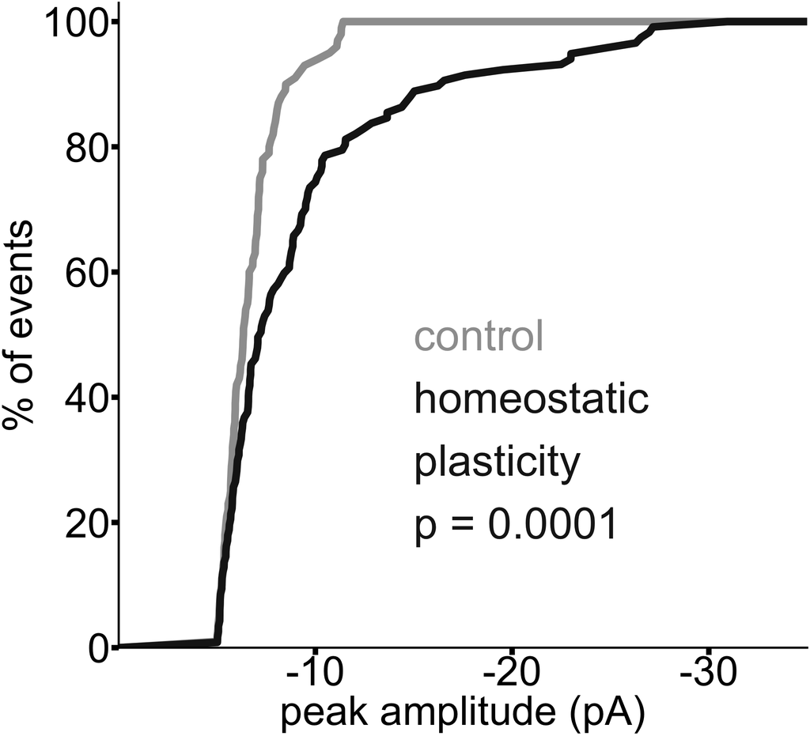

```r
set.seed(20261109)
figs12f_plot <- ggplot(Events, aes(Peak_Amp, color = Condition)) +
  stat_ecdf(geom = "line", linewidth = 7) +
  annotate("text", x = -15, y = 0.5, label = "control",
           color = "#9E9E9E", hjust = 0, size = 30) +
  annotate("text", x = -15, y = 0.3, label = paste0("homeostatic\nplasticity\np = ", stats_table$`p value`[1]),
           color = "#1A1A1A", hjust = 0, size = 30) +
  scale_x_reverse(oob = scales::oob_keep, limits = c(0, -35), breaks = c(-10, -20, -30), expand = c(0, 0)) +
  scale_y_continuous(oob = scales::oob_keep, limits = c(0, 1.03), breaks = seq(0, 1, 0.2),
                     labels = function(x) x * 100, expand = c(0, 0)) +
  scale_color_manual(values = condition_colors) +
  labs(x = "peak amplitude (pA)", y = "% of events") +
  theme_classic() +
  theme(axis.title = element_text(size = 80, color = "black"),
        axis.text = element_text(size = 80, color = "black"),
        axis.ticks = element_line(linewidth = 5, color = "black"),
        axis.ticks.length = grid::unit(0.5, "cm"),
        axis.line = element_line(linewidth = 2, color = "black"),
        legend.position = "none")

figs12f_plot
```

# Fig S12G

Mitochondrial pH time courses used to correct ATP measurements in Fig 6G.

**update for 2026 pending** — The source contains group means and SEs. Individual pH traces and replicate IDs are unavailable.

**Source data**  
`Fig S12G.csv`

**Columns**

- `Control` — Mean mitochondrial pH in control neurons
- `Control_SE` — SE of the corresponding mean pH
- `PKI` — Mean mitochondrial pH in Matrix-PKI neurons
- `PKI_SE` — SE of the corresponding mean pH

## Data

Measurements are spaced 20 s apart, with nine baseline observations and a post-induction interval from 2 to 12 min.

```r
suppressPackageStartupMessages({
  library(dplyr); library(readr); library(ggplot2); library(ggtext)
})

N_BASELINE_POINTS <- 9
TIME_INTERVAL_SECONDS <- 20
POST_STIM_START_MINUTES <- 2
ERRORBAR_TIMEPOINTS <- c(3, 9, 10)
ERRORBAR_TIMES <- c(4, 6, 8, 10, 12)
X_BREAKS <- c(-2, 0, 2, 4, 6, 8, 10, 12)
Y_LIMITS <- c(6.6, 7.5)
Y_BREAKS <- c(6.6, 6.8, 7.0, 7.2, 7.4)
condition_order <- c("Control", "PKI")
condition_colors <- c(Control = "#777B7E", PKI = "#1A1A1A")

row_to_minutes <- function(timepoint) {
  ifelse(timepoint <= N_BASELINE_POINTS,
         (timepoint - N_BASELINE_POINTS) * TIME_INTERVAL_SECONDS / 60,
         POST_STIM_START_MINUTES +
           (timepoint - N_BASELINE_POINTS - 1) * TIME_INTERVAL_SECONDS / 60)
}

pH_wide <- read_csv("./Fig S12G.csv", show_col_types = FALSE)
required_columns <- c("Control", "Control_SE", "PKI", "PKI_SE")
missing_columns <- setdiff(required_columns, names(pH_wide))
if (length(missing_columns)) stop("Missing columns: ", paste(missing_columns, collapse = ", "))

pH_data <- bind_rows(
  pH_wide %>% transmute(Timepoint = row_number(), Condition = "Control",
                        pH = as.numeric(Control), SE = as.numeric(Control_SE)),
  pH_wide %>% transmute(Timepoint = row_number(), Condition = "PKI",
                        pH = as.numeric(PKI), SE = as.numeric(PKI_SE))
) %>%
  mutate(Time = row_to_minutes(Timepoint),
         Condition = factor(Condition, levels = condition_order)) %>%
  filter(is.finite(Time), is.finite(pH)) %>%
  arrange(Condition, Timepoint)

if (!nrow(pH_data)) stop("No valid pH measurements were found.")
if (any(count(pH_data, Condition)$n < N_BASELINE_POINTS))
  stop("Each condition must contain at least nine baseline time points.")

pH_wide %>% mutate(across(all_of(required_columns), ~ round(as.numeric(.x), 3)))
```

| Control | Control_SE | PKI | PKI_SE |
| --- | --- | --- | --- |
| 7.189 | 0.062 | 6.758 | 0.067 |
| 7.314 | 0.119 | 6.795 | 0.073 |
| 7.292 | 0.085 | 6.825 | 0.080 |
| 7.280 | 0.068 | 6.843 | 0.089 |
| 7.289 | 0.108 | 6.864 | 0.084 |
| 7.287 | 0.086 | 6.878 | 0.083 |
| 7.342 | 0.109 | 6.890 | 0.090 |
| 7.321 | 0.091 | 6.906 | 0.082 |
| 7.284 | 0.064 | 6.936 | 0.095 |
| 7.006 | 0.038 | 6.765 | 0.108 |

[output cut: 30 more lines]

## Summary

```r
baseline_table <- pH_data %>%
  filter(Timepoint <= N_BASELINE_POINTS) %>%
  group_by(Condition) %>%
  summarise(`Baseline mean pH` = mean(pH), .groups = "drop") %>%
  mutate(`Baseline mean pH` = round(`Baseline mean pH`, 3))

baseline_table
```

| Condition | Baseline mean pH |
| --- | --- |
| Control | 7.289 |
| PKI | 6.855 |

## Statistics

Mean ± SE.

## Plot

The red bar marks single-spine induction from 0 to 2 min.

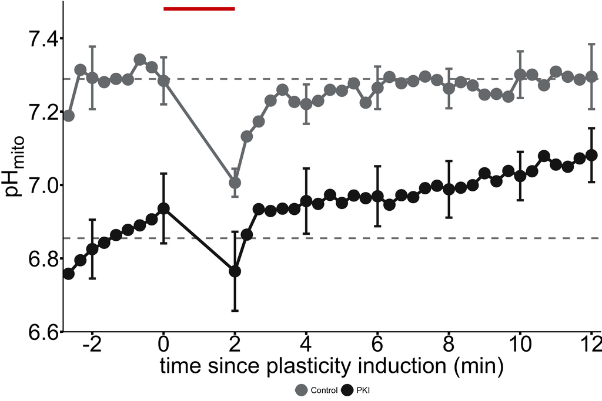

```r
set.seed(20261109)
baseline_lines <- baseline_table %>%
  transmute(Condition, baseline_pH = `Baseline mean pH`)

pH_errorbars <- pH_data %>%
  filter(Timepoint %in% ERRORBAR_TIMEPOINTS |
           round(Time, 6) %in% round(ERRORBAR_TIMES, 6),
         is.finite(SE))

figs12g_plot <- ggplot(pH_data, aes(Time, pH, color = Condition, group = Condition)) +
  geom_hline(data = baseline_lines, aes(yintercept = baseline_pH),
             inherit.aes = FALSE, color = "grey50", linetype = "dashed", linewidth = 3) +
  geom_line(linewidth = 5) +
  geom_point(size = 20) +
  geom_errorbar(data = pH_errorbars, aes(ymin = pH - SE, ymax = pH + SE),
                width = 0.2, linewidth = 4, na.rm = TRUE) +
  scale_color_manual(values = condition_colors, breaks = condition_order) +
  scale_x_continuous(breaks = X_BREAKS, labels = X_BREAKS,
                     expand = expansion(add = c(0.15, 0.15))) +
  scale_y_continuous(oob = scales::oob_keep, limits = Y_LIMITS, breaks = Y_BREAKS, expand = c(0, 0)) +
  labs(x = "time since plasticity induction (min)", y = "pH<sub>mito</sub>") +
  annotate("segment",x=0,xend=2,y=7.48,yend=7.48,color="#D00000",linewidth=6) +
  theme_classic() +
  theme(axis.title.x = element_text(size = 80, color = "black"),
        axis.title.y = ggtext::element_markdown(size = 80, color = "black"),
        axis.text = element_text(size = 80, color = "black"),
        axis.ticks = element_line(linewidth = 4, color = "black"),
        axis.ticks.length = grid::unit(0.4, "cm"),
        axis.line = element_line(linewidth = 2, color = "black"),
        legend.position = "bottom", legend.text = element_text(size=30), legend.title = element_blank())

figs12g_plot
```